# Price vs X

### Number of Purchases

Notes:

```r
?transform
```

```r
summary(yo)
```

```
      obs               id            time         strawberry        blueberry        pina.colada          plain         mixed.berry         price
 Min.   :   1.0   2132290:  74   Min.   : 9662   Min.   : 0.0000   Min.   : 0.0000   Min.   : 0.0000   Min.   :0.0000   Min.   :0.0000   Min.   :20.00
 1st Qu.: 696.5   2130583:  59   1st Qu.: 9843   1st Qu.: 0.0000   1st Qu.: 0.0000   1st Qu.: 0.0000   1st Qu.:0.0000   1st Qu.:0.0000   1st Qu.:50.00
 Median :1369.5   2124073:  50   Median :10045   Median : 0.0000   Median : 0.0000   Median : 0.0000   Median :0.0000   Median :0.0000   Median :65.04
 Mean   :1367.8   2149500:  50   Mean   :10050   Mean   : 0.6492   Mean   : 0.3571   Mean   : 0.3584   Mean   :0.2176   Mean   :0.3887   Mean   :59.25
 3rd Qu.:2044.2   2101790:  47   3rd Qu.:10255   3rd Qu.: 1.0000   3rd Qu.: 0.0000   3rd Qu.: 0.0000   3rd Qu.:0.0000   3rd Qu.:0.0000   3rd Qu.:68.96
 Max.   :2743.0   2129528:  39   Max.   :10459   Max.   :11.0000   Max.   :12.0000   Max.   :10.0000   Max.   :6.0000   Max.   :8.0000   Max.   :68.96
                  (Other):2061
 all.pruchases
 Min.   : 1.000
 1st Qu.: 1.000
 Median : 2.000
 Mean   : 1.971
 3rd Qu.: 2.000
 Max.   :21.000
```

```r
length(unique(yo$price))
```

```
[1] 20
```

```r
table(yo$price)
```

```
   20 24.96 33.04  33.2 33.28 33.36 33.52 39.04    44 45.04 48.96 49.52  49.6    50 55.04 58.96    62 63.04 65.04 68.96
    2    11    54     1     1    22     1   234    21    11    81     1     1   205     6   303    15     2   799   609
```

```r
# Create a new variable called all.purchases,
# which gives the total counts of yogurt for
# each observation or household.
# One way to do this is using the transform
# function. You can look up the function transform
# and run the examples of code at the bottom of the
# documentation to figure out what it does.
# The transform function produces a data frame
# so if you use it then save the result to 'yo'!
# OR you can figure out another way to create the
# variable.
yo <- transform(yo, all.purchases = strawberry + blueberry + pina.colada + plain + mixed.berry)
summary(yo)
```

```
      obs               id            time         strawberry        blueberry        pina.colada          plain         mixed.berry         price
 Min.   :   1.0   2132290:  74   Min.   : 9662   Min.   : 0.0000   Min.   : 0.0000   Min.   : 0.0000   Min.   :0.0000   Min.   :0.0000   Min.   :20.00
 1st Qu.: 696.5   2130583:  59   1st Qu.: 9843   1st Qu.: 0.0000   1st Qu.: 0.0000   1st Qu.: 0.0000   1st Qu.:0.0000   1st Qu.:0.0000   1st Qu.:50.00
 Median :1369.5   2124073:  50   Median :10045   Median : 0.0000   Median : 0.0000   Median : 0.0000   Median :0.0000   Median :0.0000   Median :65.04
 Mean   :1367.8   2149500:  50   Mean   :10050   Mean   : 0.6492   Mean   : 0.3571   Mean   : 0.3584   Mean   :0.2176   Mean   :0.3887   Mean   :59.25
 3rd Qu.:2044.2   2101790:  47   3rd Qu.:10255   3rd Qu.: 1.0000   3rd Qu.: 0.0000   3rd Qu.: 0.0000   3rd Qu.:0.0000   3rd Qu.:0.0000   3rd Qu.:68.96
 Max.   :2743.0   2129528:  39   Max.   :10459   Max.   :11.0000   Max.   :12.0000   Max.   :10.0000   Max.   :6.0000   Max.   :8.0000   Max.   :68.96
                  (Other):2061
 all.pruchases    all.purchases
 Min.   : 1.000   Min.   : 1.000
 1st Qu.: 1.000   1st Qu.: 1.000
 Median : 2.000   Median : 2.000
 Mean   : 1.971   Mean   : 1.971
 3rd Qu.: 2.000   3rd Qu.: 2.000
 Max.   :21.000   Max.   :21.000
```

```r
# Alternative 1
# yo$all.purchases <- yo$strawberry + yo$blueberry + yo$pina.colada + yo$plain + yo$mixed.berry
# Alternative 2
# with(yo, all.pruchases <- strawberry + blueberry + pina.colada + plain + mixed.berry)
yo$all.pruchases <- NULL
```

### Prices over Time

Notes:

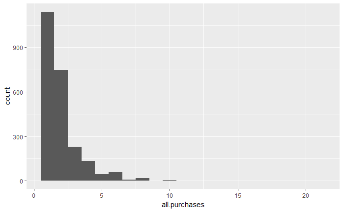

```r
ggplot(yo, aes(all.purchases)) +
  geom_histogram(binwidth = 1)
```

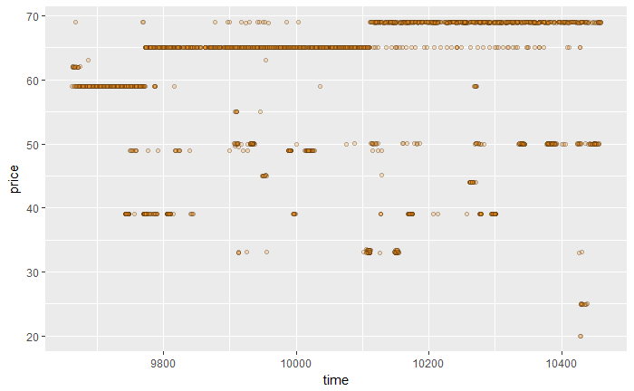

```r
ggplot(yo, aes(time, price)) +
  geom_jitter(alpha = 0.25, shape = 21, fill = I('#F79420'))
```

### Sampling Observations

Notes:

### Looking at Samples of Households

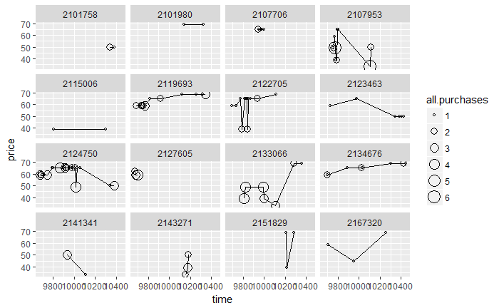

```r
set.seed(4230)
sample.ids <- sample(levels(yo$id), 16)
ggplot(subset(yo, id %in% sample.ids), aes(time, price)) +
  facet_wrap(~id) +
  geom_line() +
  geom_point(aes(size = all.purchases), pch = 1)
```

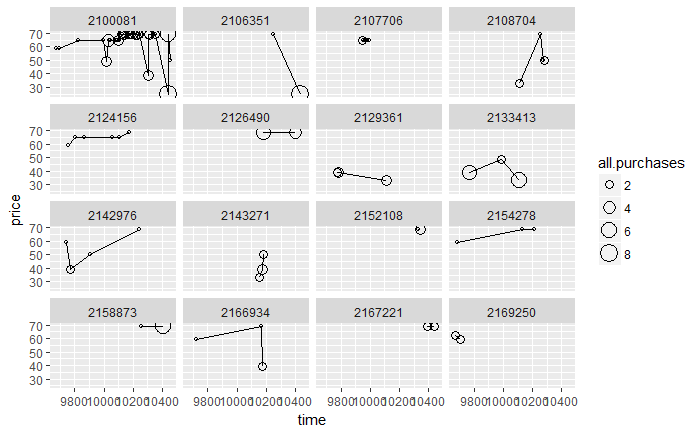

```r
set.seed(1111)
sample.ids <- sample(levels(yo$id), 16)
ggplot(subset(yo, id %in% sample.ids), aes(time, price)) +
  facet_wrap(~id) +
  geom_line() +
  geom_point(aes(size = all.purchases), pch = 1)
```

### The Limits of Cross Sectional Data

Notes:

### Many Variables

Notes:

### Scatterplot Matrices

Notes:

```r
install.packages('GGally')
```

```r
library(GGally)
theme_set(theme_minimal(20))
#set the seed for reproducible results
set.seed(1836)
pf_subset <- pf[, c(2:15)]
names(pf_subset)
```

```
 [1] "age"                   "dob_day"               "dob_year"              "dob_month"             "gender"                "tenure"
 [7] "friend_count"          "friendships_initiated" "likes"                 "likes_received"        "mobile_likes"          "mobile_likes_received"
[13] "www_likes"             "www_likes_received"
```

[output not shown]

[figure not shown]

```r
ggpairs(pf_subset[sample.int(nrow(pf_subset), 1000), ])
```

### Even More Variables

Notes:

### Heat Maps

Notes:

```r
nci <- read.table("nci.tsv")
colnames(nci) <- c(1:64)
```

```r
nci.long.samp <- melt(as.matrix(nci[1:200,]))
names(nci.long.samp) <- c("gene", "case", "value")
head(nci.long.samp)
```

|  | gene | case | value |
| --- | --- | --- | --- |
| 1 | 1 | 1 | 0.300 |
| 2 | 2 | 1 | 1.180 |
| 3 | 3 | 1 | 0.550 |
| 4 | 4 | 1 | 1.140 |
| 5 | 5 | 1 | -0.265 |
| 6 | 6 | 1 | -0.070 |

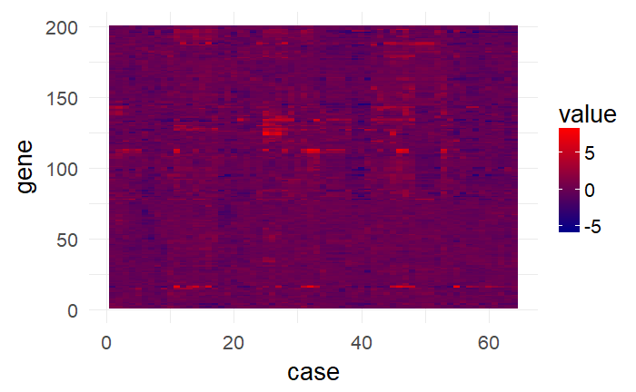

```r
ggplot(aes(y = gene, x = case, fill = value),
  data = nci.long.samp) +
  geom_tile() +
  scale_fill_gradientn(colours = colorRampPalette(c("darkblue", "red"))(100))
```

### Analyzing Three of More Variables

Reflection: We have learnt how to express more than 2 variables in a plot. First of all, we segmented by gender, applying a color pattern inside the aes() function in a geom_line plot. After that, we customized some cuts in years in order to get a better distribution of friend count by age based in the tenure of people.

We have also learnt that some datasets have limitations as they don’t allow you to inspect the behavior of a particular sample over the time, as we did with the Yogurt’s dataset, where we could inspect a user (with an unique id) and its consumer behavior over the time and the influence of yogurt prices on it.

Finally, we found a first approach to get the big picture of the relation between multiple variable with the scatterplot matrix and the heat map. This could make it easier to pick at first sight the relevant cases you may want to inspect in-depth

## Problem set: Explore Many Variables

```r
library(ggplot2)
data(diamonds)
summary(diamonds)
```

```
     carat               cut        color        clarity          depth           table           price             x                y
 Min.   :0.2000   Fair     : 1610   D: 6775   SI1    :13065   Min.   :43.00   Min.   :43.00   Min.   :  326   Min.   : 0.000   Min.   : 0.000
 1st Qu.:0.4000   Good     : 4906   E: 9797   VS2    :12258   1st Qu.:61.00   1st Qu.:56.00   1st Qu.:  950   1st Qu.: 4.710   1st Qu.: 4.720
 Median :0.7000   Very Good:12082   F: 9542   SI2    : 9194   Median :61.80   Median :57.00   Median : 2401   Median : 5.700   Median : 5.710
 Mean   :0.7979   Premium  :13791   G:11292   VS1    : 8171   Mean   :61.75   Mean   :57.46   Mean   : 3933   Mean   : 5.731   Mean   : 5.735
 3rd Qu.:1.0400   Ideal    :21551   H: 8304   VVS2   : 5066   3rd Qu.:62.50   3rd Qu.:59.00   3rd Qu.: 5324   3rd Qu.: 6.540   3rd Qu.: 6.540
 Max.   :5.0100                     I: 5422   VVS1   : 3655   Max.   :79.00   Max.   :95.00   Max.   :18823   Max.   :10.740   Max.   :58.900
                                    J: 2808   (Other): 2531
       z
 Min.   : 0.000
 1st Qu.: 2.910
 Median : 3.530
 Mean   : 3.539
 3rd Qu.: 4.040
 Max.   :31.800
```

```r
quantile(diamonds$price, .90)
```

```
 90%
9821
```

### Problem 1: Price Histograms with Facet and Color

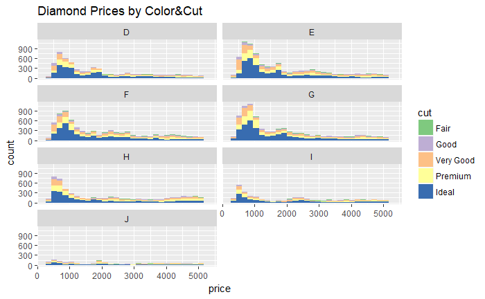

```r
# Create a histogram of diamond prices.
# Facet the histogram by diamond color
# and use cut to color the histogram bars.
# The plot should look something like this.
# http://i.imgur.com/b5xyrOu.jpg
# Note: In the link, a color palette of type
# 'qual' was used to color the histogram using
# scale_fill_brewer(type = 'qual')
# This assignment is not graded and
# will be marked as correct when you submit.
ggplot(diamonds, aes(price)) +
  geom_histogram(aes(fill = cut)) +
  facet_wrap(~color, ncol = 2) +
  xlim(250, quantile(diamonds$price, .75)) +
  scale_fill_brewer(type = 'qual') +
  labs(title = "Diamond Prices by Color&Cut")
```

## Problem 2: Price vs. Table Colored by Cut

```r
# Create a scatterplot of diamond price vs.
# table and color the points by the cut of
# the diamond.
# The plot should look something like this.
# http://i.imgur.com/rQF9jQr.jpg
# Note: In the link, a color palette of type
# 'qual' was used to color the scatterplot using
# scale_color_brewer(type = 'qual')
range(diamonds$table)
```

```
[1] 43 95
```

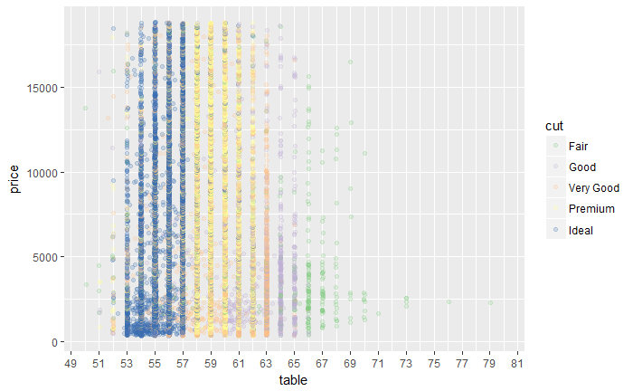

```r
ggplot(diamonds, aes(table, price)) +
  geom_jitter(aes(color = cut), alpha = 0.2) +
  scale_color_brewer(type = 'qual') +
  scale_x_continuous(limits = c(50,80), breaks = seq(43, 95, 2))
```

## Problem 3: Typical Table Value

Question: What is the typical range for the majority of diamonds of ideal cut?

53-57

What is the typical range for the majority of diamonds of premium cut?

(Use the graph that you created from the previous exercise to see the answer. You do not need to run summaries.)

## Problem 4: Price vs. Volume and Diamond Clarity

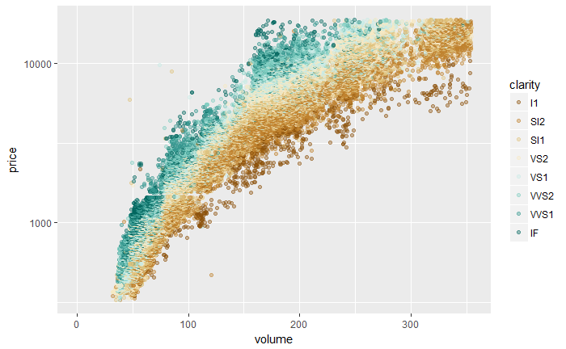

```r
# Create a scatterplot of diamond price vs.
# volume (x * y * z) and color the points by
# the clarity of diamonds. Use scale on the y-axis
# to take the log10 of price. You should also
# omit the top 1% of diamond volumes from the plot.
# Note: Volume is a very rough approximation of
# a diamond's actual volume.
# The plot should look something like this.
# http://i.imgur.com/excUpea.jpg
# Note: In the link, a color palette of type
# 'div' was used to color the scatterplot using
# scale_color_brewer(type = 'div')
diamonds <- transform(diamonds, volume = x * y * z)
diamonds$volume[diamonds$volume == 0] <- NA
ggplot(diamonds, aes(volume, price)) +
  geom_jitter(aes(color = clarity), alpha = 0.4) +
  scale_x_continuous(limits = c(0, quantile(diamonds$volume, 0.99, na.rm=TRUE))) +
  scale_y_continuous(trans = "log10") +
  scale_color_brewer(type = 'div')
```

## Problem 5: Proportion of Friendships Initiated

```r
# Many interesting variables are derived from two or more others.
# For example, we might wonder how much of a person's network on
# a service like Facebook the user actively initiated. Two users
# with the same degree (or number of friends) might be very
# different if one initiated most of those connections on the
# service, while the other initiated very few. So it could be
# useful to consider this proportion of existing friendships that
# the user initiated. This might be a good predictor of how active
# a user is compared with their peers, or other traits, such as
# personality (i.e., is this person an extrovert?).
# Your task is to create a new variable called 'prop_initiated'
# in the Pseudo-Facebook data set. The variable should contain
# the proportion of friendships that the user initiated.
# This programming assignment WILL BE automatically graded.
pf <- read.csv('pseudo_facebook.tsv', sep = "\t")
pf <- transform(pf, prop_initiated = friendships_initiated/friend_count)
```

## Problem 6: prop_initiated vs. tenure

```r
?cut
```

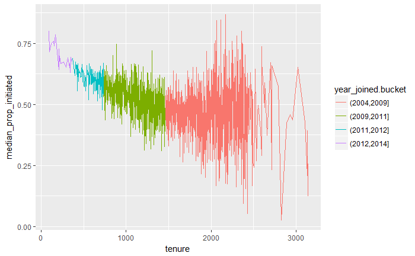

```r
# Create a line graph of the median proportion of
# friendships initiated ('prop_initiated') vs.
# tenure and color the line segment by
# year_joined.bucket.
# Recall, we created year_joined.bucket in Lesson 5
# by first creating year_joined from the variable tenure.
# Then, we used the cut function on year_joined to create
# four bins or cohorts of users.
# (2004, 2009]
# (2009, 2011]
# (2011, 2012]
# (2012, 2014]
# The plot should look something like this.
# http://i.imgur.com/vNjPtDh.jpg
# OR this
# http://i.imgur.com/IBN1ufQ.jpg
library(dplyr)
# Add year_joined column
pf$year_joined <- floor(2014 - pf$tenure/365)
# Alternative: pf$year_joined <- 2014-ceiling(pf$tenure/365)
# Add bucket column
pf$year_joined.bucket <- cut(pf$year_joined, c(2004, 2009, 2011, 2012, 2014), right = TRUE)
ggplot(pf.prop_by_tenure, aes(tenure, median_prop_initiated)) +
  geom_line(aes(color = year_joined.bucket), stat = 'summary', fun.y = median, na.rm = TRUE)
```

## Problem 7: Smoothing prop_initiated vs. tenure

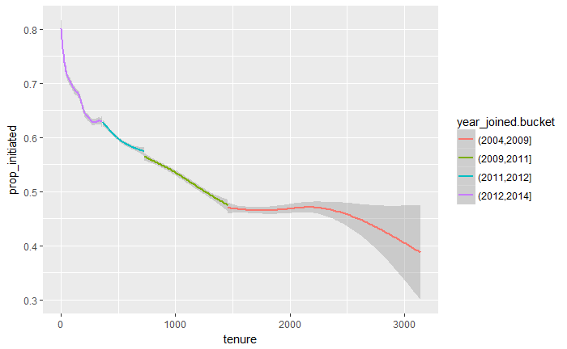

```r
# Smooth the last plot you created of
# of prop_initiated vs tenure colored by
# year_joined.bucket. You can bin together ranges
# of tenure or add a smoother to the plot.
# There won't be a solution image for this exercise.
# You will answer some questions about your plot in
# the next two exercises.
ggplot(pf, aes(tenure, prop_initiated)) +
  geom_smooth(aes(color = year_joined.bucket), na.rm = TRUE)
```

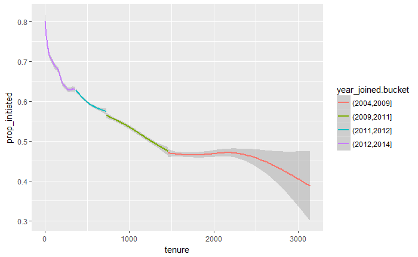

```r
ggplot(pf, aes(x=tenure, y=prop_initiated, color=year_joined.bucket)) +
  geom_smooth(na.rm=TRUE)
```

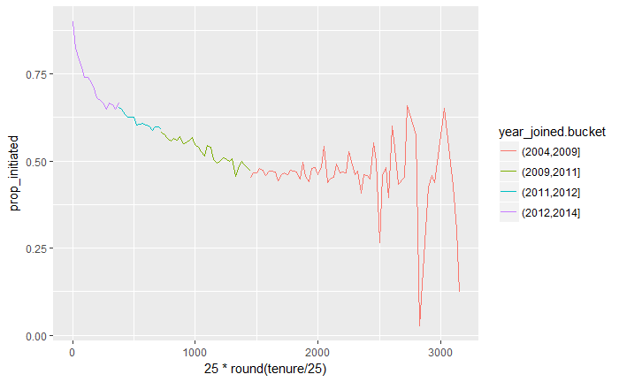

```r
ggplot(pf, aes(x=25*round(tenure/25), y=prop_initiated, color=year_joined.bucket)) +
  geom_line(stat='summary', fun.y=median, na.rm=TRUE)
```

## Problem 8: Greatest prop_initiated group

On average, which group initiated the greatest proportion of its Facebook friendships? The plot with the smoother that you created in the last exercise can help you answer this question

- People who joined after 2012

## Problem 9: Largest Group Mean prop_initiated

```r
mean(pf$prop_initiated[pf$year_joined.bucket=='(2012,2014]'], na.rm=TRUE)
```

```
[1] 0.6653892
```

## Problem 10: Price/Carat Binned, Faceted, & Colored

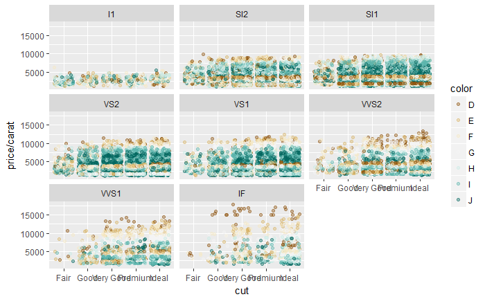

```r
# Create a scatter plot of the price/carat ratio
# of diamonds. The variable x should be
# assigned to cut. The points should be colored
# by diamond color, and the plot should be
# faceted by clarity.
# The plot should look something like this.
# http://i.imgur.com/YzbWkHT.jpg.
# Note: In the link, a color palette of type
# 'div' was used to color the histogram using
# scale_color_brewer(type = 'div')
ggplot(diamonds, aes(cut, price/carat)) +
  geom_jitter(aes(color = color), alpha = 0.4) +
  facet_wrap(~clarity) +
  scale_color_brewer(type = 'div')
```

Problem 11: Gapminder Multivariate Analysis

```r
# The Gapminder website contains over 500 data sets with information about
# the world's population. Your task is to continue the investigation you did at the
# end of Problem Set 4 or you can start fresh and choose a different
# data set from Gapminder.

# If you're feeling adventurous or want to try some data munging see if you can
# find a data set or scrape one from the web.

# In your investigation, examine 3 or more variables and create 2-5 plots that make
# use of the techniques from Lesson 5.

# You can find a link to the Gapminder website in the Instructor Notes.

# Once you've completed your investigation, create a post in the discussions that includes:
#       1. the variable(s) you investigated, your observations, and any summary statistics
#       2. snippets of code that created the plots
#       3. links to the images of your plots
```

Click **KnitHTML** to see all of your hard work and to have an html page of this lesson, your answers, and your notes!